# Cyclistic - Case study

Google-data-analytics-capstone-project

Mohammed Raif

2022-09-26

#### **Introduction**

As a part of Google’s Data Analytics certification course by Coursera, I have chosen the Cyclistic dataset for my capstone project. For this case study, and to answer all key business questions asked in this project, I will follow the six steps of Google data analysis process which are below:

- Ask
- Prepare
- Process
- Analyze
- Share
- Act

##### **The Scenario**

As a junior data analyst working in the marketing analyst team at Cyclistic, a bike-share company in Chicago, my task is to understand how casual riders and annual members use Cyclistic bikes differently. From these insights, my team will design a new marketing strategy to convert casual riders into annual members.

##### **Characters and Teams**

- Cyclistic: A bike-share program that features more than 5,800 bicycles and 600 docking stations. Cyclistic sets itself apart by also offering reclining bikes, hand tricycles, and cargo bikes, making bike-share more inclusive to people with disabilities and riders who can’t use a standard two-wheeled bike. The majority of riders opt for traditional bikes; about 8% of riders use the assistive options. Cyclistic users are more likely to ride for leisure, but about 30% use them to commute to work each day.
- Lily Moreno: The director of marketing and your manager. Moreno is responsible for the development of campaigns and initiatives to promote the bike-share program. These may include email, social media, and other channels.
- Cyclistic marketing analytics team: A team of data analysts who are responsible for collecting, analyzing, and reporting data that helps guide Cyclistic marketing strategy.
- Cyclistic executive team: The notoriously detail-oriented executive team will decide whether to approve the recommended marketing program.

##### The **Ask** Phase

Business Task: To come up with a marketing strategy and campaigns to convert casual riders to annual members, as annual members are more profitable to the company.

Key stakeholders:

- Lily Moreno: The director of marketing and my manager.
- Cyclistic executive team: The team which will decide whether to approve the recommended marketing program which will be presented by our marketing team.

##### The **Prepare** Phase

The main data set has been downloaded and stored in .csv files.

- Data sets have been named following the naming convention.
- Data is current; data from the last twelve months will be used for this analysis i.e. from 09-2021 to 08-2022.
- Data is complete and accurate for the analysis. However, it requires thorough cleaning as inspected each file in spreadsheet.
- Data is collected and provided by Motivate International Inc.- Primary source
- The data has full credibility because it’s reliable, original, comprehensive, current and cited(ROCCC).

##### *Tools used*

- Spreadsheet - All 12 data sets needed inspection to check if all of the data is accurate and reliable.
- R - For data cleaning and manipulation,to analyze the data and for data visualization.

##### *Setting up the environment*

Loading necessary packages:

```r
library(tidyverse)
```

```r
library(ggplot2)
library(lubridate)
```

**To change working directory and Import raw data .csv files**

setwd(“C:\Users\Raif\Downloads\divvy_tripdata_CSV”)

Imported data:

data_01<-read.csv(“202109-divvy-tripdata.csv”)  
data_02<-read.csv(“202110-divvy-tripdata.csv”)  
data_03<-read.csv(“202111-divvy-tripdata.csv”)  
data_04<-read.csv(“202112-divvy-tripdata.csv”)  
data_05<-read.csv(“202201-divvy-tripdata.csv”)  
data_06<-read.csv(“202202-divvy-tripdata.csv”)  
data_07<-read.csv(“202203-divvy-tripdata.csv”)  
data_08<-read.csv(“202204-divvy-tripdata.csv”)  
data_09<-read.csv(“202205-divvy-tripdata.csv”)  
data_10<-read.csv(“202206-divvy-tripdata.csv”)  
data_11<-read.csv(“202207-divvy-tripdata.csv”)  
data_12<-read.csv(“202208-divvy-tripdata.csv”)

##### *Data Wrangling and Manipulation*

Binding individual monthly data frames into one big data frame

```r
all_data <- rbind(data_01,data_02,data_03,data_04,data_05,data_06,
                  data_07,data_08,data_09,data_10,data_11,data_12)
```

Inspecting all_data table by using, str,head,glimpse,colnames,summary etc

```r
str(all_data)
```

```
## 'data.frame':    5883043 obs. of  13 variables:
##  $ ride_id           : chr  "9DC7B962304CBFD8" "F930E2C6872D6B32" "6EF72137900BB910" "78D1DE133B3DBF55" ...
##  $ rideable_type     : chr  "electric_bike" "electric_bike" "electric_bike" "electric_bike" ...
##  $ started_at        : chr  "2021-09-28 16:07:10" "2021-09-28 14:24:51" "2021-09-28 00:20:16" "2021-09-28 14:51:17" ...
##  $ ended_at          : chr  "2021-09-28 16:09:54" "2021-09-28 14:40:05" "2021-09-28 00:23:57" "2021-09-28 15:00:06" ...
##  $ start_station_name: chr  "" "" "" "" ...
##  $ start_station_id  : chr  "" "" "" "" ...
##  $ end_station_name  : chr  "" "" "" "" ...
##  $ end_station_id    : chr  "" "" "" "" ...
##  $ start_lat         : num  41.9 41.9 41.8 41.8 41.9 ...
##  $ start_lng         : num  -87.7 -87.6 -87.7 -87.7 -87.7 ...
##  $ end_lat           : num  41.9 42 41.8 41.8 41.9 ...
##  $ end_lng           : num  -87.7 -87.7 -87.7 -87.7 -87.7 ...
##  $ member_casual     : chr  "casual" "casual" "casual" "casual" ...
```

```r
head(all_data)
```

```
##            ride_id rideable_type          started_at            ended_at
## 1 9DC7B962304CBFD8 electric_bike 2021-09-28 16:07:10 2021-09-28 16:09:54
## 2 F930E2C6872D6B32 electric_bike 2021-09-28 14:24:51 2021-09-28 14:40:05
## 3 6EF72137900BB910 electric_bike 2021-09-28 00:20:16 2021-09-28 00:23:57
## 4 78D1DE133B3DBF55 electric_bike 2021-09-28 14:51:17 2021-09-28 15:00:06
## 5 E03D4ACDCAEF6E00 electric_bike 2021-09-28 09:53:12 2021-09-28 10:03:44
## 6 346DE323A2677DC0 electric_bike 2021-09-28 01:53:18 2021-09-28 02:00:02
##   start_station_name start_station_id end_station_name end_station_id start_lat
## 1                                                                         41.89
## 2                                                                         41.94
## 3                                                                         41.81
## 4                                                                         41.80
## 5                                                                         41.88
## 6                                                                         41.87
##   start_lng end_lat end_lng member_casual
## 1    -87.68   41.89  -87.67        casual
## 2    -87.64   41.98  -87.67        casual
## 3    -87.72   41.80  -87.72        casual
## 4    -87.72   41.81  -87.72        casual
## 5    -87.74   41.88  -87.71        casual
## 6    -87.75   41.88  -87.74        casual
```

```r
glimpse(all_data)
```

```
## Rows: 5,883,043
## Columns: 13
## $ ride_id            <chr> "9DC7B962304CBFD8", "F930E2C6872D6B32", "6EF7213790…
## $ rideable_type      <chr> "electric_bike", "electric_bike", "electric_bike", …
## $ started_at         <chr> "2021-09-28 16:07:10", "2021-09-28 14:24:51", "2021…
## $ ended_at           <chr> "2021-09-28 16:09:54", "2021-09-28 14:40:05", "2021…
## $ start_station_name <chr> "", "", "", "", "", "", "", "", "", "", "Clark St &…
## $ start_station_id   <chr> "", "", "", "", "", "", "", "", "", "", "TA13070001…
## $ end_station_name   <chr> "", "", "", "", "", "", "", "", "", "", "", "", "",…
## $ end_station_id     <chr> "", "", "", "", "", "", "", "", "", "", "", "", "",…
## $ start_lat          <dbl> 41.89000, 41.94000, 41.81000, 41.80000, 41.88000, 4…
## $ start_lng          <dbl> -87.68000, -87.64000, -87.72000, -87.72000, -87.740…
## $ end_lat            <dbl> 41.89, 41.98, 41.80, 41.81, 41.88, 41.88, 41.74, 41…
## $ end_lng            <dbl> -87.67, -87.67, -87.72, -87.72, -87.71, -87.74, -87…
## $ member_casual      <chr> "casual", "casual", "casual", "casual", "casual", "…
```

Rename column names for better understanding

```r
all_data <- rename(all_data,
                   user_id=ride_id,
                   bike_type=rideable_type,
                   start_time=started_at,
                   end_time=ended_at,
                   start_station=start_station_name,
                   end_station=end_station_name,
                   membership_type=member_casual)
```

Verify and delete unnecessary columns

```r
colnames(all_data)
```

```
##  [1] "user_id"          "bike_type"        "start_time"       "end_time"
##  [5] "start_station"    "start_station_id" "end_station"      "end_station_id"
##  [9] "start_lat"        "start_lng"        "end_lat"          "end_lng"
## [13] "membership_type"
```

```r
all_data<- all_data %>%
  select(-c(start_station_id,end_station_id:end_lng))
```

Delete all blanks and NA cells

```r
all_data[all_data==""]<- NA
clean_data <- na.omit(all_data)
```

Add new columns required for the analysis

```r
clean_data$start_date <- as.Date(clean_data$start_time)
clean_data$start_month <- format(as.Date(clean_data$start_date),"%B")
clean_data$start_day <- format(as.Date(clean_data$start_date),"%d")
clean_data$start_year <- format(as.Date(clean_data$start_date),"%Y")
clean_data$day_of_week <- format(as.Date(clean_data$start_date),"%A")
```

Change data type to numeric for start year and start day

```r
clean_data$start_day <- as.numeric(as.character(clean_data$start_day))
clean_data$start_year <- as.numeric(as.character(clean_data$start_year))
```

Reorder columns for better data frame format

```r
clean_data_v2 <- clean_data[, c(1, 2, 7, 3, 4, 5, 6, 8, 9, 10, 11, 12)]
```

Additional column required - length of the ride named as *ride_time* in numeric format

```r
clean_data_v2$ride_time <- difftime(clean_data_v2$end_time,clean_data_v2$start_time)

clean_data_v2$ride_time <- as.numeric(as.character(clean_data_v2$ride_time))
```

Check and delete if there are any negative values in *ride_time*

```r
clean_data_v2 <- arrange(clean_data_v2,ride_time)
clean_data_v2[clean_data_v2 < 0] <- NA  #convert negative values to NA
cleaned_data <- na.omit(clean_data_v2) #deleting NA values
```

##### *Descriptive analysis on ride_time*

```r
mean(cleaned_data$ride_time) #straight average
```

```
## [1] 1079.989
```

```r
median(cleaned_data$ride_time)
```

```
## [1] 660
```

```r
max(cleaned_data$ride_time) #longest ride
```

```
## [1] 2442301
```

```r
min(cleaned_data$ride_time) #shortest ride
```

```
## [1] 0
```

All above analysis can be done in one line using summary()

```r
summary(cleaned_data$ride_time)
```

```
##    Min. 1st Qu.  Median    Mean 3rd Qu.    Max.
##       0     377     660    1080    1185 2442301
```

*The Average length of the ride is 1080 secs.*

Compare members and casual users

```r
aggregate(cleaned_data$ride_time ~ cleaned_data$membership_type, FUN = mean)
```

```
##   cleaned_data$membership_type cleaned_data$ride_time
## 1                       casual              1547.3404
## 2                       member               752.7599
```

```r
aggregate(cleaned_data$ride_time ~ cleaned_data$membership_type, FUN = median)
```

```
##   cleaned_data$membership_type cleaned_data$ride_time
## 1                       casual                    881
## 2                       member                    547
```

```r
aggregate(cleaned_data$ride_time ~ cleaned_data$membership_type, FUN = max)
```

```
##   cleaned_data$membership_type cleaned_data$ride_time
## 1                       casual                2442301
## 2                       member                  89575
```

```r
aggregate(cleaned_data$ride_time ~ cleaned_data$membership_type, FUN = min)
```

```
##   cleaned_data$membership_type cleaned_data$ride_time
## 1                       casual                      0
## 2                       member                      0
```

*The Average length of the ride for* casual - 1547.3404 member - 752.7599

Rearrange weekdays and months as per order to do weekly analysis

```r
cleaned_data$day_of_week <- ordered(cleaned_data$day_of_week, levels
=c("Sunday", "Monday", "Tuesday", "Wednesday", "Thursday", "Friday", "Saturday"))

cleaned_data$start_month <- ordered(cleaned_data$start_month, levels
= c("January", "February", "March", "April", "May", "June", "July","August","September","October" , "November","December"))
```

Average ride time by each day and month for members vs casual users

```r
aggregate(cleaned_data$ride_time ~ cleaned_data$membership_type +
          cleaned_data$day_of_week, FUN = mean)
```

```
##    cleaned_data$membership_type cleaned_data$day_of_week cleaned_data$ride_time
## 1                        casual                   Sunday              1783.3532
## 2                        member                   Sunday               848.0548
## 3                        casual                   Monday              1606.5988
## 4                        member                   Monday               729.5837
## 5                        casual                  Tuesday              1354.4082
## 6                        member                  Tuesday               708.7638
## 7                        casual                Wednesday              1324.9433
## 8                        member                Wednesday               715.2242
## 9                        casual                 Thursday              1366.4177
## 10                       member                 Thursday               722.5401
## 11                       casual                   Friday              1441.8046
## 12                       member                   Friday               736.0905
## 13                       casual                 Saturday              1703.3012
## 14                       member                 Saturday               845.2271
```

```r
aggregate(cleaned_data$ride_time ~ cleaned_data$membership_type +
           cleaned_data$start_month, FUN = mean)
```

```
##    cleaned_data$membership_type cleaned_data$start_month cleaned_data$ride_time
## 1                        casual                  January              1641.3145
## 2                        member                  January               616.1954
## 3                        casual                 February              1489.4124
## 4                        member                 February               638.6797
## 5                        casual                    March              1706.2311
## 6                        member                    March               707.7860
## 7                        casual                    April              1556.8131
## 8                        member                    April               696.5622
## 9                        casual                      May              1662.2873
## 10                       member                      May               798.0496
## 11                       casual                     June              1501.1415
## 12                       member                     June               821.0144
## 13                       casual                     July              1505.5999
## 14                       member                     July               810.1973
## 15                       casual                   August              1397.0642
## 16                       member                   August               786.3640
## 17                       casual                September              1685.2759
## 18                       member                September               787.8606
## 19                       casual                  October              1578.8406
## 20                       member                  October               720.8677
## 21                       casual                 November              1348.9644
## 22                       member                 November               657.0941
## 23                       casual                 December              1490.5845
## 24                       member                 December               634.8756
```

*For both as per day and month analysis the average length of the length is much higher for casual riders than members. It is shown in below chart as well.*

*Weekly analysis*

```r
#checking ride_time on weekday basis
cleaned_data %>%
  group_by(day_of_week) %>%
  summarise(number_of_rides = n())
```

```
## # A tibble: 7 × 2
##   day_of_week number_of_rides
##   <ord>                 <int>
## 1 Sunday               657833
## 2 Monday               597634
## 3 Tuesday              632407
## 4 Wednesday            651611
## 5 Thursday             643966
## 6 Friday               623681
## 7 Saturday             752915
```

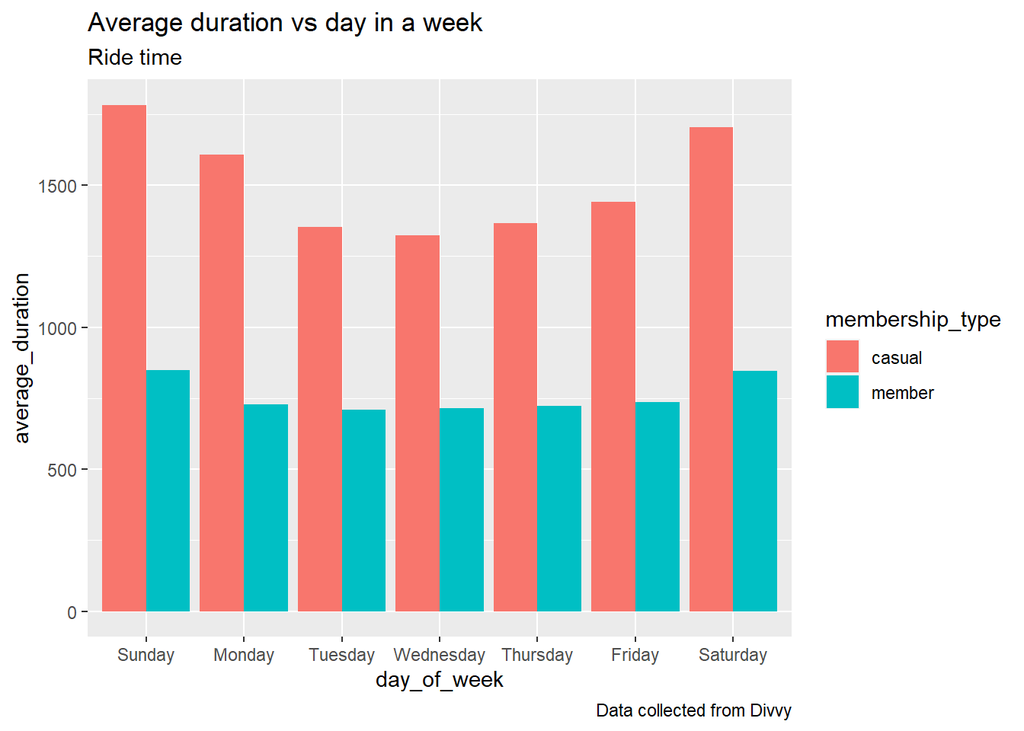

```r
#Plot-1 Average_duration for every day of the week for members and casual riders.
cleaned_data%>%
  group_by(membership_type, day_of_week) %>%
  summarise(number_of_rides = n(),average_duration = mean(ride_time)) %>%
  arrange(membership_type, day_of_week) %>%
  ggplot(aes(x = day_of_week, y = average_duration, fill=membership_type))+
  labs(title = "Average duration vs day in a week", subtitle = "Ride time", caption = "Data collected from Divvy")+
  geom_col(position = "dodge")
```

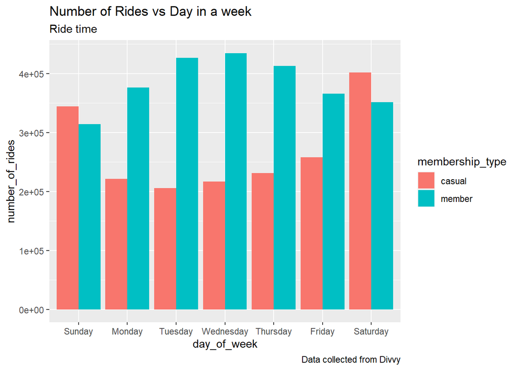

```r
#Plot-2 Number of riders each day of the week for members and casual riders.
cleaned_data%>%
  group_by(membership_type, day_of_week) %>%
  summarise(number_of_rides = n()) %>%
  arrange(membership_type, day_of_week) %>%
  ggplot(aes(x = day_of_week, y=number_of_rides, fill=membership_type))+
  labs(title = "Number of Rides vs Day in a week", subtitle = "Ride time",caption = "Data collected from Divvy")+
  geom_col(position = "dodge")
```

*Monthly analysis*

```r
#checking ride_time on monthly basis
cleaned_data %>%
  group_by(start_month) %>%
  summarise(number_of_rides = n())
```

```
## # A tibble: 12 × 2
##    start_month number_of_rides
##    <ord>                 <int>
##  1 January               80128
##  2 February              89178
##  3 March                215981
##  4 April                272560
##  5 May                  502545
##  6 June                 620348
##  7 July                 642666
##  8 August               605313
##  9 September            621118
## 10 October              477972
## 11 November             255867
## 12 December             176371
```

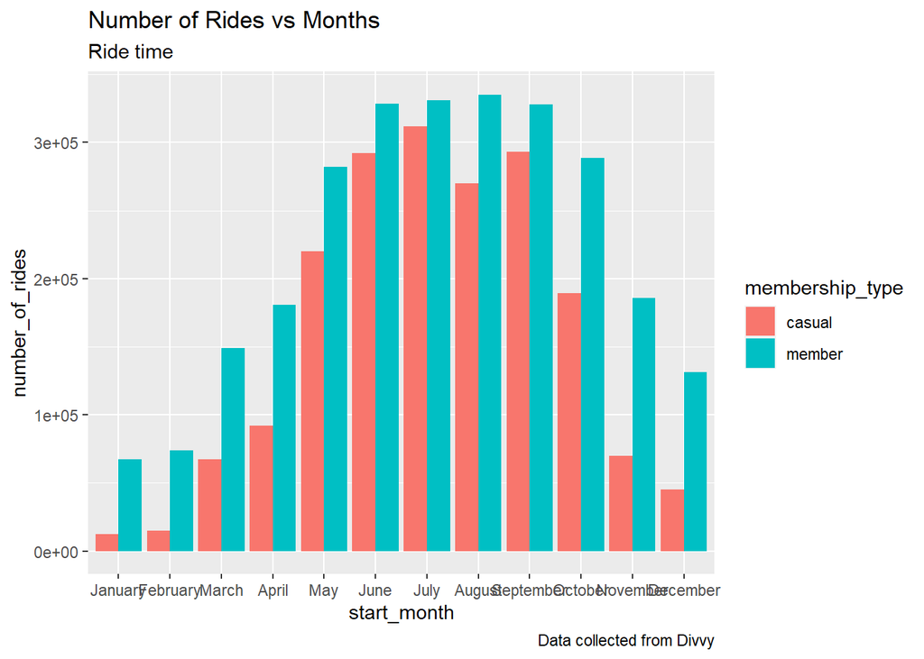

```r
#Plot-3 Number of riders per month for members and casual riders.
cleaned_data %>%
  group_by(membership_type, start_month) %>%
  summarise(number_of_rides = n()) %>%
  arrange(membership_type, start_month) %>%
  ggplot(aes(x = start_month, y = number_of_rides, fill=membership_type))+
  labs(title = "Number of Rides vs Months", subtitle = "Ride time",caption =
         "Data collected from Divvy")+
  geom_col(position = "dodge")
```

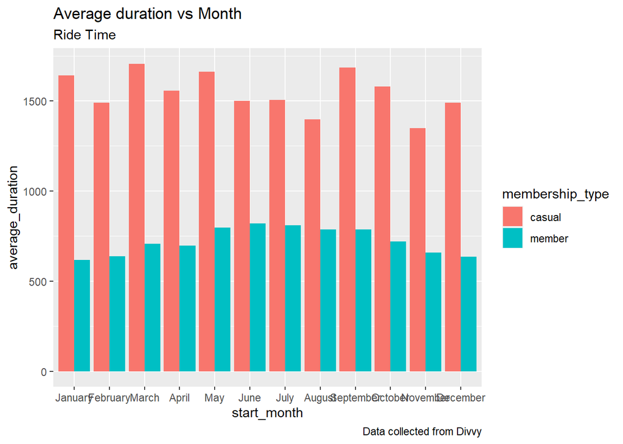

```r
#PLot-4 Average_duration for each month for members and casual riders.
cleaned_data%>%
  group_by(membership_type, start_month) %>%
  summarise(number_of_rides = n(),average_duration = mean(ride_time)) %>%
  arrange(membership_type, start_month) %>%
  ggplot(aes(x = start_month, y = average_duration, fill=membership_type))+
  labs(title = "Average duration vs Month", subtitle = "Ride Time",
       caption = "Data collected from Divvy")+
  geom_col(position = "dodge")
```

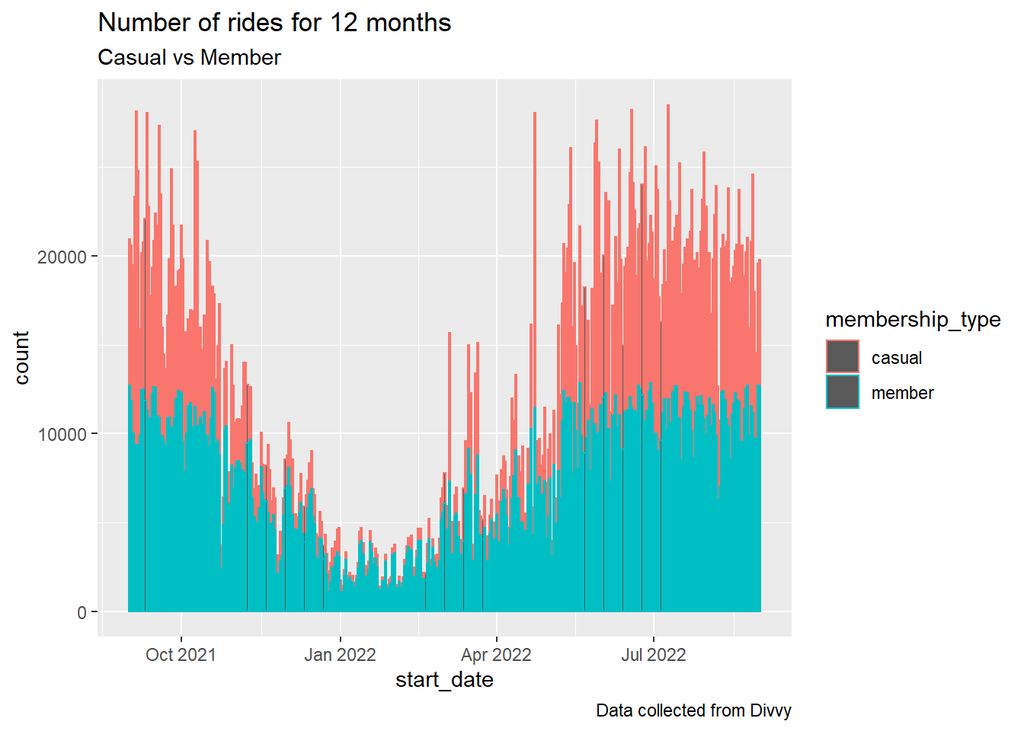

```r
#Plot-5 Number of rides monthly(time series)
cleaned_data %>%
  ggplot(mapping = aes(x = start_date, color = membership_type))+
  geom_bar()+
  labs(title = "Number of rides for 12 months", subtitle = "Casual vs Member",
       caption = "Data collected from Divvy")
```

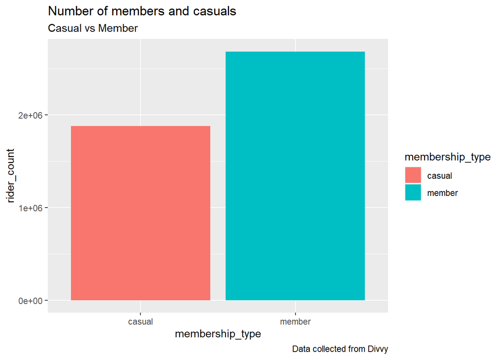

```r
#Plot-6 The overall rider count based on membership type
cleaned_data %>%
  group_by(membership_type) %>%
  summarise(rider_count = n()) %>%
  ggplot(aes(x = membership_type, y = rider_count,fill=membership_type )) +
  labs(title = "Number of members and casuals", subtitle = "Casual vs Member",
       caption = "Data collected from Divvy")+
  geom_col()
```

##### *Conclusions/Summary of Insights*

There is huge difference between members and casual in-terms of how bikes are rented, when bikes are rented and which days the bike are rented.

##### *Recommendations*

- Company can come up with a referral program for its members, where for every new annual membership from their referral gets few minutes of free usage of the rides.
- Giving additional benefits or discounts to the members for using during weekends and for longer rides than their usual rides.
- The marketing campaign should be launched between October to May, as the number of conversion is low during this period and a campaign can give a boost.
- Campaign for weekends should be done to promote longer rides and to increase the usage for members, such as weekends promotions and benefits for members.

##### The **Act** Phase

Taking into consideration each team members’ insights and recommendations, Lily Moreno, the director of marketing, will come up with marketing strategies and campaigns which will be presented to the Cyclistic Executive Team, who, in turn, will decide whether to act on it or not.

*END*